# Lyu et al. (2018): reproducing BaSyc and Table 2

2026-11-08

```r
knitr::opts_chunk$set(echo = TRUE, collapse = TRUE, comment = "#>",
                      warning = TRUE, error = FALSE, fig.align = "center")
# Supports both the shared project root and this exercise's own folder.
lyu_dir <- if (file.exists("Lyu_2018/R/mtpi2.R")) "Lyu_2018" else "."
for (file in c("mtpi2", "basyc", "mts", "table2_helpers")) {
  source(file.path(lyu_dir, "R", paste0(file, ".R")))
}
```

# 1 Scope and main finding

This report reconstructs the **hypothetical trial in Table 2**, not the paper’s simulation tables. It uses the patient-level toxicity outcomes printed in the paper and **computes the doses from the appendix rules**. The expected doses are a separate reference file; they are never passed to the decision engine.

The replay matches **all 45 dose assignments**, all 30 continuation Go decisions, all 15 final exits, and the week-56 completion. It reproduces all nine final dose/cycle count cells. There is one apparent typo among the 63 printed cumulative count cells: at week 40, cycle 3 D2, the patient rows give **1/3**, whereas the printed total is **1/6**.

Three files contain the statistical functions: `R/mtpi2.R`, `R/basyc.R`, and `R/mts.R`. The short helper file handles report formatting and independent reference comparisons. The design code uses **base R only**. Knitting this report needs `rmarkdown` and `knitr`.

Use the shared `phase1-dose-finding.Rproj` in the parent folder. This exercise has no separate R project or render helper. From the shared project root, run `rmarkdown::render("Lyu_2018/reproduce_table2.Rmd")` or `source("Lyu_2018/validate.R")`; from this folder, use `rmarkdown::render("reproduce_table2.Rmd")` or `source("validate.R")`. All generated tables stay in this exercise’s `results/` folder.

The primary source is Lyu, Curran and Ji (2018), [DOI 10.1200/PO.18.00020](https://doi.org/10.1200/PO.18.00020): Figure 2 on p. 5; Table 2 on pp. 6-8; appendix on pp. 16-18.

# 2 The appendix rules in executable form

## 2.1 Independent beta-binomial working models

Let $d$ index dose and $j$ index cycle. For each dose/cycle cell, accumulate **all observed outcomes at that cell**, across cohorts:

$$x_{dj}\mid n_{dj},p_{dj}\sim\operatorname{Binomial}(n_{dj},p_{dj}),
\qquad p_{dj}\sim\operatorname{Beta}(1,1),$$

$$p_{dj}\mid D\sim\operatorname{Beta}(1+x_{dj},1+n_{dj}-x_{dj}),
\qquad r_{dj}=\Pr(p_{dj}>p_T\mid D).$$

These are working models for trial decisions. They do not fit a parametric longitudinal toxicity or carryover model. The final sequence TPC calculation is a separate step.

```r
settings <- basyc_settings(n_dose = 3, target = 0.30,
                           ei = c(0.25, 0.35), xi = 0.95)
settings
```

```
#> $n_dose
#> [1] 3
#>
#> $target
#> [1] 0.3
#>
#> $ei
#> [1] 0.25 0.35
#>
#> $xi
#> [1] 0.95
#>
#> $safety_min_n
#> [1] 0
```

## 2.2 The reusable mTPI-2 module

The equivalence interval is $(0.25,0.35)$. Split the lower and upper tails into intervals of width 0.10, truncating only the intervals at 0 and 1. For each interval $I$, compute

$$\operatorname{UPM}(I)=\frac{\Pr(p\in I\mid x,n)}{|I|}.$$

The interval with the largest UPM gives E (below the EI), S (in the EI), or D (above the EI). The posterior overdose rule adds DU when $r>0.95$. The code evaluates the **same small module separately at different dose/cycle cells**. It never merges the current-cycle and next-cycle counts.

```r
mtpi2_intervals(settings$ei)
```

```
#>    lower upper action
#> 1   0.00  0.05      E
#> 2   0.05  0.15      E
#> 3   0.15  0.25      E
#> 4   0.25  0.35      S
#> 5   0.35  0.45      D
#> 6   0.45  0.55      D
#> 7   0.55  0.65      D
#> 8   0.65  0.75      D
#> 9   0.75  0.85      D
#> 10  0.85  0.95      D
#> 11  0.95  1.00      D
```

```r
examples <- data.frame(x = c(0, 1, 3), n = c(3, 3, 6))
examples$decision <- mapply(mtpi2_decision, examples$x, examples$n,
                            MoreArgs = list(settings = settings))
knitr::kable(examples, caption = "Three mTPI-2 decisions used in the replay")
```

Three mTPI-2 decisions used in the replay

| x | n | decision |
| --- | --- | --- |
| 0 | 3 | E |
| 1 | 3 | S |
| 3 | 6 | D |

```r
# Inspect every interval's posterior mass and UPM for 1 DLT in 3 patients.
knitr::kable(mtpi2_scores(1, 3, settings), digits = 5)
```

| lower | upper | action | probability | upm |
| --- | --- | --- | --- | --- |
| 0.00 | 0.05 | E | 0.01402 | 0.28038 |
| 0.05 | 0.15 | E | 0.09550 | 0.95500 |
| 0.15 | 0.25 | E | 0.15220 | 1.52200 |
| 0.25 | 0.35 | S | 0.17530 | 1.75300 |
| 0.35 | 0.45 | D | 0.17200 | 1.72000 |
| 0.45 | 0.55 | D | 0.14950 | 1.49500 |
| 0.55 | 0.65 | D | 0.11500 | 1.15000 |
| 0.65 | 0.75 | D | 0.07570 | 0.75700 |
| 0.75 | 0.85 | D | 0.03880 | 0.38800 |
| 0.85 | 0.95 | D | 0.01150 | 0.11500 |
| 0.95 | 1.00 | D | 0.00048 | 0.00962 |

For zero observations the implementation returns S. Exact UPM ties prefer D, then S, then E. These explicit conventions do not affect Table 2.

## 2.3 Continuation and safety

For a cohort completing cycle $j<J$, DCR examines the lowest dose in the **destination cycle**:

$$\mathrm{DCR}(j)=
\begin{cases}
\mathrm{NG},&r_{1,j+1}>\xi,\\
\mathrm{G},&r_{1,j+1}\le\xi.
\end{cases}$$

Patients exit after the last cycle. Additionally, the trial stops when any cycle’s lowest dose satisfies $r_{1j}>\xi$. If dose $d$ in cycle $j$ is unsafe, exclude all $(d',j')$ with $d'\ge d$ and $j'\ge j$, permanently. Global trial stopping takes precedence over further continuation or allocation.

## 2.4 DAR-1, DAR-2a and DAR-2b

Write $T(d,j)$ for the candidate dose index returned by the cell-specific mTPI-2 module, bounded to the available dose range.

- **Default:** cohort 1 receives D1 in every cycle, subject to continuation.
- **DAR-1:** a new cohort’s cycle-1 dose is $T(d_{\mathrm{previous}},1)$, using the preceding cohort’s cycle-1 dose and cumulative cell data.
- For an existing patient moving from $j$ to $j+1$, set $i_1=T(d,j)$. If the previous cohort used several doses in cycle $j+1$, calculate all their candidates and take

$$i_2=\min_{u\in\{\text{previous cohort's doses in cycle
}j+1\}}T(u,j+1).$$

Then use the current patient’s observed toxicity $Y$:

$$d_{\mathrm{next}}=
\begin{cases}
\min(i_1,i_2),&Y=0\quad\text{(DAR-2a)},\\
\min\{\max(d-1,1),i_2\},&Y=1\quad\text{(DAR-2b)}.
\end{cases}$$

Thus, after a DLT at D1, the patient can remain at D1 if continuation is allowed. A DLT does not automatically remove an individual from all later cycles: the motivating trial assumes washout and recovery.

`dar2()` handles each patient separately using the same rule. This preserves the personalized split: patients sharing a dose and current outcome receive the same decision. All distinct doses used by the previous cohort are included in $i_2$ even when that cohort has split into subcohorts.

# 3 Reconstruct Table 2 from outcomes

## 3.1 Read only the toxicity inputs

The CSV codes O as 0 and X as 1. Dose paths are not in this input file.

```r
input <- read.csv(lyu_path("data", "table2_outcomes.csv"))
knitr::kable(input, caption = "Patient-level outcomes transcribed from Table 2")
```

Patient-level outcomes transcribed from Table 2

| patient | cohort | y1 | y2 | y3 |
| --- | --- | --- | --- | --- |
| 1 | 1 | 0 | 0 | 0 |
| 2 | 1 | 0 | 0 | 1 |
| 3 | 1 | 0 | 0 | 0 |
| 4 | 2 | 1 | 0 | 0 |
| 5 | 2 | 0 | 0 | 0 |
| 6 | 2 | 0 | 1 | 0 |
| 7 | 3 | 0 | 0 | 1 |
| 8 | 3 | 1 | 0 | 0 |
| 9 | 3 | 1 | 0 | 0 |
| 10 | 4 | 0 | 0 | 0 |
| 11 | 4 | 0 | 0 | 1 |
| 12 | 4 | 1 | 0 | 0 |
| 13 | 5 | 0 | 1 | 1 |
| 14 | 5 | 0 | 0 | 1 |
| 15 | 5 | 1 | 0 | 0 |

```r
outcomes <- as.matrix(input[, c("y1", "y2", "y3")])
```

## 3.2 Run the design

At each eight-week epoch, the engine observes **all outcomes due at that time**, updates cumulative counts and safety, then makes allocation decisions. It enrolls a new cohort after the preceding cohort finishes cycle 1. The preceding cohort’s destination-cycle outcomes are observed before being used in DAR-2. No future outcome is used.

```r
fit <- run_basyc(outcomes, cohort_size = 3, cycle_weeks = 8,
                 settings = settings)
data.frame(Patients = fit$n_patient, Observed_patient_cycles = nrow(fit$observed),
           End_week = fit$end_week, Stopped_early = fit$stopped)
```

```
#>   Patients Observed_patient_cycles End_week Stopped_early
#> 1       15                      45       56         FALSE
```

## 3.3 Inspect the split at week 16

The cycle-1 D2 data are 1/3, giving candidate D2; the destination cycle-2 D1 data are 0/3, also giving candidate D2. Patients 5-6 therefore receive D2. Patient 4 experienced a DLT, so DAR-2b lowers that patient’s dose to D1.

```r
knitr::kable(subset(fit$assignments, week == 16 & cohort == 2,
                    select = c(patient, cycle, rule, current, i1, i2, dose)))
```

|  | patient | cycle | rule | current | i1 | i2 | dose |
| --- | --- | --- | --- | --- | --- | --- | --- |
| 13 | 4 | 2 | DAR-2b | D2 C1: 1/3 S | 2 | 2 | 1 |
| 14 | 5 | 2 | DAR-2a | D2 C1: 1/3 S | 2 | 2 | 2 |
| 15 | 6 | 2 | DAR-2a | D2 C1: 1/3 S | 2 | 2 | 2 |

## 3.4 Inspect the previous cohort’s split at week 24

Cohort 2 used D1 and D2 in cycle 2. Both modules contribute to cohort 3’s destination-cycle candidate: D1 has 0/4 and suggests D2, but D2 has 1/2 and suggests D1. Their minimum is D1. Current cycle-1 D2 also has 3/6 and suggests D1. All three patients in cohort 3 receive D1 in cycle 2.

```r
knitr::kable(subset(fit$assignments, week == 24 & cohort == 3,
                    select = c(patient, rule, current, previous, i1, i2, dose)))
```

|  | patient | rule | current | previous | i1 | i2 | dose |
| --- | --- | --- | --- | --- | --- | --- | --- |
| 22 | 7 | DAR-2a | D2 C1: 3/6 D | D1 C2: 0/4 E -> D2; D2 C2: 1/2 D -> D1 | 1 | 1 | 1 |
| 23 | 8 | DAR-2b | D2 C1: 3/6 D | D1 C2: 0/4 E -> D2; D2 C2: 1/2 D -> D1 | 1 | 1 | 1 |
| 24 | 9 | DAR-2b | D2 C1: 3/6 D | D1 C2: 0/4 E -> D2; D2 C2: 1/2 D -> D1 | 1 | 1 | 1 |

# 4 Table 2, assessment by assessment

The following panels preserve the patient-level information in Table 2, using a compact layout. **O/X at D# is observed; Assigned D# is a planned next cycle whose outcome is not available yet.** Historical completed patients are left as individual rows instead of being compressed with an asterisk. The count rows contain observed patients only.

```r
for (week in seq(8, 56, by = 8)) {
  cat("\n\n## Week ", week, "\n\n", sep = "")
  print(knitr::kable(table2_at_week(fit, week), format = "html",
                     table.attr = "class='table table-condensed'"))
  cat("\n\n")
  s <- fit$snapshots[[as.character(week)]]
  cells <- matrix(paste0(s$x, "/", s$n), nrow = settings$n_dose)
  count_table <- data.frame(Cycle = seq_len(fit$n_cycle), t(cells), check.names = FALSE)
  names(count_table)[-1] <- paste0("D", seq_len(settings$n_dose))
  print(knitr::kable(count_table, format = "html",
                     table.attr = "class='table table-condensed'",
                     caption = "Cumulative DLTs / observed patients"))
  cat("\n\n")
}
```

## 4.1 Week 8

| Cohort | Patient | Cycle 1 | Cycle 2 | Cycle 3 | Status |
| --- | --- | --- | --- | --- | --- |
| 1 | 1 | O at D1 | Assigned D1 |  | Go to cycle 2 |
| 1 | 2 | O at D1 | Assigned D1 |  | Go to cycle 2 |
| 1 | 3 | O at D1 | Assigned D1 |  | Go to cycle 2 |
| 2 | 4 | Assigned D2 |  |  | Enrolled |
| 2 | 5 | Assigned D2 |  |  | Enrolled |
| 2 | 6 | Assigned D2 |  |  | Enrolled |

Cumulative DLTs / observed patients

| Cycle | D1 | D2 | D3 |
| --- | --- | --- | --- |
| 1 | 0/3 | 0/0 | 0/0 |
| 2 | 0/0 | 0/0 | 0/0 |
| 3 | 0/0 | 0/0 | 0/0 |

## 4.2 Week 16

| Cohort | Patient | Cycle 1 | Cycle 2 | Cycle 3 | Status |
| --- | --- | --- | --- | --- | --- |
| 1 | 1 | O at D1 | O at D1 | Assigned D1 | Go to cycle 3 |
| 1 | 2 | O at D1 | O at D1 | Assigned D1 | Go to cycle 3 |
| 1 | 3 | O at D1 | O at D1 | Assigned D1 | Go to cycle 3 |
| 2 | 4 | X at D2 | Assigned D1 |  | Go to cycle 2 |
| 2 | 5 | O at D2 | Assigned D2 |  | Go to cycle 2 |
| 2 | 6 | O at D2 | Assigned D2 |  | Go to cycle 2 |
| 3 | 7 | Assigned D2 |  |  | Enrolled |
| 3 | 8 | Assigned D2 |  |  | Enrolled |
| 3 | 9 | Assigned D2 |  |  | Enrolled |

Cumulative DLTs / observed patients

| Cycle | D1 | D2 | D3 |
| --- | --- | --- | --- |
| 1 | 0/3 | 1/3 | 0/0 |
| 2 | 0/3 | 0/0 | 0/0 |
| 3 | 0/0 | 0/0 | 0/0 |

## 4.3 Week 24

| Cohort | Patient | Cycle 1 | Cycle 2 | Cycle 3 | Status |
| --- | --- | --- | --- | --- | --- |
| 1 | 1 | O at D1 | O at D1 | O at D1 | Exit |
| 1 | 2 | O at D1 | O at D1 | X at D1 | Exit |
| 1 | 3 | O at D1 | O at D1 | O at D1 | Exit |
| 2 | 4 | X at D2 | O at D1 | Assigned D1 | Go to cycle 3 |
| 2 | 5 | O at D2 | O at D2 | Assigned D1 | Go to cycle 3 |
| 2 | 6 | O at D2 | X at D2 | Assigned D1 | Go to cycle 3 |
| 3 | 7 | O at D2 | Assigned D1 |  | Go to cycle 2 |
| 3 | 8 | X at D2 | Assigned D1 |  | Go to cycle 2 |
| 3 | 9 | X at D2 | Assigned D1 |  | Go to cycle 2 |
| 4 | 10 | Assigned D1 |  |  | Enrolled |
| 4 | 11 | Assigned D1 |  |  | Enrolled |
| 4 | 12 | Assigned D1 |  |  | Enrolled |

Cumulative DLTs / observed patients

| Cycle | D1 | D2 | D3 |
| --- | --- | --- | --- |
| 1 | 0/3 | 3/6 | 0/0 |
| 2 | 0/4 | 1/2 | 0/0 |
| 3 | 1/3 | 0/0 | 0/0 |

## 4.4 Week 32

| Cohort | Patient | Cycle 1 | Cycle 2 | Cycle 3 | Status |
| --- | --- | --- | --- | --- | --- |
| 1 | 1 | O at D1 | O at D1 | O at D1 | Exit |
| 1 | 2 | O at D1 | O at D1 | X at D1 | Exit |
| 1 | 3 | O at D1 | O at D1 | O at D1 | Exit |
| 2 | 4 | X at D2 | O at D1 | O at D1 | Exit |
| 2 | 5 | O at D2 | O at D2 | O at D1 | Exit |
| 2 | 6 | O at D2 | X at D2 | O at D1 | Exit |
| 3 | 7 | O at D2 | O at D1 | Assigned D2 | Go to cycle 3 |
| 3 | 8 | X at D2 | O at D1 | Assigned D2 | Go to cycle 3 |
| 3 | 9 | X at D2 | O at D1 | Assigned D2 | Go to cycle 3 |
| 4 | 10 | O at D1 | Assigned D2 |  | Go to cycle 2 |
| 4 | 11 | O at D1 | Assigned D2 |  | Go to cycle 2 |
| 4 | 12 | X at D1 | Assigned D1 |  | Go to cycle 2 |
| 5 | 13 | Assigned D2 |  |  | Enrolled |
| 5 | 14 | Assigned D2 |  |  | Enrolled |
| 5 | 15 | Assigned D2 |  |  | Enrolled |

Cumulative DLTs / observed patients

| Cycle | D1 | D2 | D3 |
| --- | --- | --- | --- |
| 1 | 1/6 | 3/6 | 0/0 |
| 2 | 0/7 | 1/2 | 0/0 |
| 3 | 1/6 | 0/0 | 0/0 |

## 4.5 Week 40

| Cohort | Patient | Cycle 1 | Cycle 2 | Cycle 3 | Status |
| --- | --- | --- | --- | --- | --- |
| 1 | 1 | O at D1 | O at D1 | O at D1 | Exit |
| 1 | 2 | O at D1 | O at D1 | X at D1 | Exit |
| 1 | 3 | O at D1 | O at D1 | O at D1 | Exit |
| 2 | 4 | X at D2 | O at D1 | O at D1 | Exit |
| 2 | 5 | O at D2 | O at D2 | O at D1 | Exit |
| 2 | 6 | O at D2 | X at D2 | O at D1 | Exit |
| 3 | 7 | O at D2 | O at D1 | X at D2 | Exit |
| 3 | 8 | X at D2 | O at D1 | O at D2 | Exit |
| 3 | 9 | X at D2 | O at D1 | O at D2 | Exit |
| 4 | 10 | O at D1 | O at D2 | Assigned D2 | Go to cycle 3 |
| 4 | 11 | O at D1 | O at D2 | Assigned D2 | Go to cycle 3 |
| 4 | 12 | X at D1 | O at D1 | Assigned D2 | Go to cycle 3 |
| 5 | 13 | O at D2 | Assigned D1 |  | Go to cycle 2 |
| 5 | 14 | O at D2 | Assigned D1 |  | Go to cycle 2 |
| 5 | 15 | X at D2 | Assigned D1 |  | Go to cycle 2 |

Cumulative DLTs / observed patients

| Cycle | D1 | D2 | D3 |
| --- | --- | --- | --- |
| 1 | 1/6 | 4/9 | 0/0 |
| 2 | 0/8 | 1/4 | 0/0 |
| 3 | 1/6 | 1/3 | 0/0 |

## 4.6 Week 48

| Cohort | Patient | Cycle 1 | Cycle 2 | Cycle 3 | Status |
| --- | --- | --- | --- | --- | --- |
| 1 | 1 | O at D1 | O at D1 | O at D1 | Exit |
| 1 | 2 | O at D1 | O at D1 | X at D1 | Exit |
| 1 | 3 | O at D1 | O at D1 | O at D1 | Exit |
| 2 | 4 | X at D2 | O at D1 | O at D1 | Exit |
| 2 | 5 | O at D2 | O at D2 | O at D1 | Exit |
| 2 | 6 | O at D2 | X at D2 | O at D1 | Exit |
| 3 | 7 | O at D2 | O at D1 | X at D2 | Exit |
| 3 | 8 | X at D2 | O at D1 | O at D2 | Exit |
| 3 | 9 | X at D2 | O at D1 | O at D2 | Exit |
| 4 | 10 | O at D1 | O at D2 | O at D2 | Exit |
| 4 | 11 | O at D1 | O at D2 | X at D2 | Exit |
| 4 | 12 | X at D1 | O at D1 | O at D2 | Exit |
| 5 | 13 | O at D2 | X at D1 | Assigned D1 | Go to cycle 3 |
| 5 | 14 | O at D2 | O at D1 | Assigned D2 | Go to cycle 3 |
| 5 | 15 | X at D2 | O at D1 | Assigned D2 | Go to cycle 3 |

Cumulative DLTs / observed patients

| Cycle | D1 | D2 | D3 |
| --- | --- | --- | --- |
| 1 | 1/6 | 4/9 | 0/0 |
| 2 | 1/11 | 1/4 | 0/0 |
| 3 | 1/6 | 2/6 | 0/0 |

## 4.7 Week 56

| Cohort | Patient | Cycle 1 | Cycle 2 | Cycle 3 | Status |
| --- | --- | --- | --- | --- | --- |
| 1 | 1 | O at D1 | O at D1 | O at D1 | Exit |
| 1 | 2 | O at D1 | O at D1 | X at D1 | Exit |
| 1 | 3 | O at D1 | O at D1 | O at D1 | Exit |
| 2 | 4 | X at D2 | O at D1 | O at D1 | Exit |
| 2 | 5 | O at D2 | O at D2 | O at D1 | Exit |
| 2 | 6 | O at D2 | X at D2 | O at D1 | Exit |
| 3 | 7 | O at D2 | O at D1 | X at D2 | Exit |
| 3 | 8 | X at D2 | O at D1 | O at D2 | Exit |
| 3 | 9 | X at D2 | O at D1 | O at D2 | Exit |
| 4 | 10 | O at D1 | O at D2 | O at D2 | Exit |
| 4 | 11 | O at D1 | O at D2 | X at D2 | Exit |
| 4 | 12 | X at D1 | O at D1 | O at D2 | Exit |
| 5 | 13 | O at D2 | X at D1 | X at D1 | Exit |
| 5 | 14 | O at D2 | O at D1 | X at D2 | Exit |
| 5 | 15 | X at D2 | O at D1 | O at D2 | Exit |

Cumulative DLTs / observed patients

| Cycle | D1 | D2 | D3 |
| --- | --- | --- | --- |
| 1 | 1/6 | 4/9 | 0/0 |
| 2 | 1/11 | 1/4 | 0/0 |
| 3 | 2/7 | 3/8 | 0/0 |

At week 48, patients 13-15 have finished cycle 2 and are assigned cycle-3 doses D1, D2, D2. At week 56 their outcomes are X, X, O, respectively. This changes cycle-3 D1 from 1/6 to 2/7 and D2 from 2/6 to 3/8.

# 5 Final MTS: an explicit implementation of Appendix p. 18

## 5.1 Sequence-specific data and posterior screening

Retain completed, actually used sequences that pass the posterior safety screen. For sequence $s$, use only patients completing that sequence:

$$\widetilde q_s=\frac{\sum_j x_{sj}}{\sum_j n_{sj}}.$$

This differs from averaging the pooled dose/cycle empirical rates used during allocation. The appendix’s screen uses **any** unsafe cycle ($\exists j$), despite an inconsistent use of the word “each” in its prose.

```r
knitr::kable(sequence_summary(fit), digits = 4)
```

|  | sequence | intensity | patients | events | patient_cycles | raw_tpc | nonincreasing | admissible |
| --- | --- | --- | --- | --- | --- | --- | --- | --- |
| 1 | 1,1,1 | 3 | 3 | 1 | 9 | 0.1111 | TRUE | TRUE |
| 6 | 1,1,2 | 4 | 1 | 1 | 3 | 0.3333 | FALSE | TRUE |
| 2 | 2,1,1 | 4 | 2 | 3 | 6 | 0.5000 | TRUE | TRUE |
| 5 | 1,2,2 | 5 | 2 | 1 | 6 | 0.1667 | FALSE | TRUE |
| 4 | 2,1,2 | 5 | 5 | 5 | 15 | 0.3333 | FALSE | TRUE |
| 3 | 2,2,1 | 5 | 2 | 1 | 6 | 0.1667 | TRUE | TRUE |

## 5.2 Orderings, PAVA and votes

Let $R$ contain the completed, observed sequences passing safety, and $N=\{s\in R:d_{s1}\ge d_{s2}\ge d_{s3}\}$. Order by intensity $I(s)=\sum_jd_{sj}$, permute equal-intensity sequences, and apply equal-weight PAVA over each full ordering $w$. Use `nearest_tie = "higher"`: among nearest-target candidates, choose the later position in that ordering. The same convention is used for pooled blocks below, at and above target. Equal PAVA weights, order enumeration and the final conservative frequency tie rule are retained.

The usual recommendation takes the most frequent nonincreasing winner:

$$D_w=\arg\min_{s\in R}|\widehat q_{sw}-0.30|,
\qquad f(s)=\sum_{w=1}^{W}\mathbf1\{D_w=s\},
\qquad \widehat s=\arg\max_{s\in N}f(s),
\quad\text{when }\max_{s\in N}f(s)>0.$$

**NO-MTS fallback:** if $N\ne\varnothing$ but every member has zero votes, keep the original PAVA fits and repeat the vote within $N$ only:

$$D_w^{F}=\arg\min_{s\in N}|\widehat q_{sw}-0.30|,
\qquad f^{F}(s)=\sum_{w=1}^{W}\mathbf1\{D_w^{F}=s\},
\qquad \widehat s=\arg\max_{s\in N}f^{F}(s).$$

The same higher-position tie rule applies in the ordinary vote and the fallback revote. Final frequency ties use the appendix’s conservative rule: lower intensity, then lower first-, second- and third-cycle doses. **Early stopping or an empty $N$ still gives no MTS.** The fallback never creates an unused sequence, relaxes safety, or refits PAVA. It completes an edge case not specified on appendix p. 18; it is not claimed to be the authors’ code.

For example, safe sequences 111, 211 and 212 with fitted TPCs $0,1/9,2/9$ give the original winner 212. Because 212 increases in the last cycle, the fallback compares 111 with 211 and recommends 211.

For Table 2, the same policy gives the following votes; the fallback is not needed. Table 2 does not publish a final MTS for comparison.

```r
mts <- select_mts(fit, weights = "equal", nearest_tie = "higher",
                   screen_min_n = 0, no_mts_fallback = "restricted_revote")
knitr::kable(mts$votes[, c("sequence", "frequency", "nonincreasing")])
```

| sequence | frequency | nonincreasing |
| --- | --- | --- |
| 1,1,1 | 0 | TRUE |
| 1,1,2 | 0 | FALSE |
| 2,1,1 | 0 | TRUE |
| 1,2,2 | 6 | FALSE |
| 2,1,2 | 0 | FALSE |
| 2,2,1 | 6 | TRUE |

```r
mts$recommendation
```

```
#> [1] "2,2,1"
```

# 6 Table 3: parallel simulation and comparison with the paper

## 6.1 Functions and the one-file workflow

The Table 2 reproduction above stays unchanged. Table 3 scenarios 1-6 use the same allocation and final-recommendation functions:

| Function | Called for |
| --- | --- |
| `simulate_table3()` in `simulate.R` | Repeating scenarios 1-6 in parallel batches |
| `run_basyc()` in `R/basyc.R` | Trial allocation, continuation and safety |
| `select_mts()` in `R/mts.R` | PAVA and final MTS selection in each trial |
| `summarize_table3()` in `simulate.R` | Summarizing the saved simulation data |
| `table3_reference()` in `simulate.R` | The transcribed published comparison values |

In a **local Mac terminal**, from the shared project folder, run:

```bash
bash unity.sh 10000 auto 2018
```

This uploads changed code, requests up to 32 currently available Slurm CPU cores, and runs 10,000 trials **per scenario for scenarios 1-6** (60,000 total), downloads **`data/table3.rds`**, and renders **this same Rmd**. The shell script requests a compute node, not computation on the login node. Password/Duo entry is private and manual. Keep the terminal open until the command finishes; do not upload new code while that job is running.

The simulation call performed on Unity is:

```r
source("Lyu_2018/simulate.R")
result <- simulate_table3(nsim = 10000, cores = 32, seed = 2018, scenarios = 1:6,
                          weights = "equal", nearest_tie = "higher",
                          safety_min_n = 4, mts_screen_min_n = 0,
                          no_mts_fallback = "restricted_revote",
                          global_monitor = "after_first_sequence")
saveRDS(result, "Lyu_2018/data/table3.rds")
```

The function uses `parallel::mclapply()` over batches of trials from scenarios 1-6. Every trial has its own seed, so changing the number of workers does not change the simulated trials. Workers never exceed `SLURM_CPUS_PER_TASK`. The RDS holds trial records, dose/cycle counts, completed patient sequences and settings together. **Knitting reads this file; it does not rerun the simulation.**

## 6.2 Scenario settings and conventions

There are three doses, three cycles, at most 15 patients and three patients per cohort. The target is 0.30, EI is (0.25, 0.35), and the posterior safety threshold is 0.95. For scenario-specific first-cycle probabilities,

$$p_{dj}=\min\{1,p_{d1}(1.1)^{j-1}\},\qquad j=1,2,3.$$

The probability cap is explicit: in scenario 4 the literal multiplier gives $0.84(1.1)^2=1.0164$ for D3 in cycle 3, which is capped at one.

Independent patient/cycle uniforms generate binary toxicity at the dose actually assigned:

$$Y_{ij}=\mathbf{1}\{U_{ij}<p_{d_{ij},j}\},\qquad
U_{ij}\overset{\mathrm{iid}}{\sim}\operatorname{Uniform}(0,1).$$

The outcome independence assumption, equal PAVA weights and within-order distance-tie convention are explicit implementation choices. The simulation uses the original PAVA ordering, `nearest_tie = "higher"`, and strict **n > 3 for intratrial safety**. Other statistical settings remain fixed.

The intratrial safety override is now

$$\operatorname{unsafe}_{dj}
=\mathbf{1}\{n_{dj}>3\}
\mathbf{1}\{\Pr(p_{dj}>0.30\mid D)>0.95\}.$$

Setting `safety_min_n = 4` implements strict n > 3. It is a simulation hypothesis: Figure 2 shows NG/DU at 3/3, while this run defers that override. The written appendix does not state a minimum.

**Global monitoring is separate from DCR in this experiment.** DCR remains active from the first cycle assessment (week 8), using its next-cycle lowest-dose posterior and the n > 3 minimum. Global termination (Rule 1) and permanent exclusion (Rule 2) both begin after the first cohort has completed all three cycles (week 24). Before activation, an mTPI-2 DU decision makes the de-escalation move but does not permanently exclude doses. Both global rules start together because exclusion alone could otherwise remove every available dose while termination is deferred.

At each assessment, observe all outcomes due and update cumulative counts first. Once global monitoring is active, evaluate safety before additional treatment or enrollment. Define

$$A(t)=\mathbf1\{\text{cohort 1 has completed all cycles by }t\},
\qquad F(t)=\mathbf1\{\text{further treatment is planned}\}.$$

$$\operatorname{EarlyStop}(t)
=A(t)F(t)\,\mathbf1\{\exists j:n_{1j}(t)>3,\quad
\Pr(p_{1j}>0.30\mid D_t)>0.95\}.$$

DCR does not use the activation indicator $A(t)$. At the final visit, all treatment has ended, so $F(t)=0$: a newly detected unsafe cell still informs exclusion and final MTS screening, but is not labelled early termination. The RDS records each trial’s global start week and the cycle, DLTs, sample size and posterior risk at an early stop.

**This delayed start is a sensitivity hypothesis, not a statement of the authors’ implementation.** The paper says the safety rules operate throughout the trial. The experiment tests an alternative initialization and assessment schedule while retaining the numerical safety boundaries and the DCR rule.

**Final MTS posterior screening remains separate:** `mts_screen_min_n = 0` retains the appendix’s unqualified screen. Permanent exclusions after global activation remain in force. A trial completed without an early stop may therefore have no MTS if its final safety screen leaves no admissible path.

The comparison below is a reproduction attempt, **not a claim that all Table 3 numbers already agree**. Increasing simulation size cannot resolve a different implementation convention.

## 6.3 Final-selection convention and NO-MTS fallback

Use the original PAVA/voting convention in Section 5.2: equal weights and higher-position within-order ties. **NO-MTS fallback:** only if all original winners are increasing, repeat the nearest-target vote among observed, safe, nonincreasing sequences using the same PAVA fits. Early stopping or no such safe sequence still gives no MTS. The fallback structure and final posterior screen are unchanged.

The strict n > 3, delayed-global-monitoring replay reproduces all Table 2 assignments, outcomes, continuation decisions and the week-56 finish. Its illustrative MTS is (2,2,1), without using a fallback. Table 2 does not publish a final MTS.

**Saved run:** 10000 trials per scenario (60000 total).

**Total simulation runtime:** 7.87 minutes (472.49 seconds).

Runtime is wall-clock simulation time, excluding queueing and file transfers.

Verified server job and runtime

| Job | Status | Partition | Node | CPUs | Queue (s) | Job (s) |
| --- | --- | --- | --- | --- | --- | --- |
| 11393218 | COMPLETED | stat | u042 | 12 | 26 | 478 |

| setting | value |
| --- | --- |
| nsim_per_scenario | 10000 |
| scenarios | 1,2,3,4,5,6 |
| cores | 12 |
| seed | 2018 |
| maximum_patients | 15 |
| cohort_size | 3 |
| cycles | 3 |
| target | 0.3 |
| EI | (0.25,0.35) |
| xi | 0.95 |
| safety_min_n | 4 |
| mts_screen_min_n | 0 |
| pava_weights | equal |
| nearest_tie | higher |
| clinical_ties | FALSE |
| no_mts_fallback | restricted_revote |
| global_monitor | after_first_sequence |
| global_exclusion_start | after_first_sequence |
| global_evaluation | before further treatment |
| outcome_generator | independent patient/cycle Bernoulli |
| probability_cap | pmin(p,1) |
| R_version | R version 4.5.1 (2025-06-13) |
| created_utc | 2026-11-10 03:37:05 UTC |
| host | u042.asc.ohio-state.edu |

## 6.4 Reading the completed comparison

The following compact table puts true-MTS selection and early termination side by side. The remaining plots show the full sequence-level comparison.

```r
true_targets <- vapply(lyu_scenarios(), lyu_true_mts, character(1))
overview <- do.call(rbind, lapply(scenarios, function(s) {
  target <- true_targets[s]
  paper <- subset(published$selection, scenario == s & sequence == target)
  sim <- subset(table3_summary$selection, scenario == s & sequence == target)
  data.frame(Scenario = s, True_MTS = target,
    Paper_correct_selection_pct = if (nrow(paper)) 100 * paper$selection else NA_real_,
    Sim_correct_selection_pct = 100 * sim$selection,
    Paper_early_stop_pct = 100 * published$early_stop$stopped_early[published$early_stop$scenario == s],
    Sim_early_stop_pct = 100 * table3_summary$early_stop$stopped_early[table3_summary$early_stop$scenario == s])
}))
knitr::kable(overview, digits = 2, row.names = FALSE)
```

| Scenario | True_MTS | Paper_correct_selection_pct | Sim_correct_selection_pct | Paper_early_stop_pct | Sim_early_stop_pct |
| --- | --- | --- | --- | --- | --- |
| 1 | 2,2,1 | 19.0 | 20.70 | 3.32 | 3.98 |
| 2 | 2,2,2 | 14.8 | 14.51 | 3.75 | 3.99 |
| 3 | 3,3,3 | 20.4 | 19.52 | 0.43 | 0.27 |
| 4 | None | NA | 97.24 | 99.21 | 96.30 |
| 5 | 2,2,2 | 39.7 | 37.14 | 0.44 | 0.25 |
| 6 | 1,1,1 | 45.0 | 45.21 | 4.01 | 3.61 |

In scenario 4, simulated “correct selection” means no MTS is recommended. The paper does not report that exact probability separately from its early termination probability, so its selection entry is left missing.

## 6.5 True toxicity curves and the true MTS

The first plot follows the true toxicity of each fixed dose across cycles. The bold black path follows the true MTS dose in each cycle. The target is 0.30 and the shaded EI is (0.25, 0.35). Scenario 4 has no safe MTS.

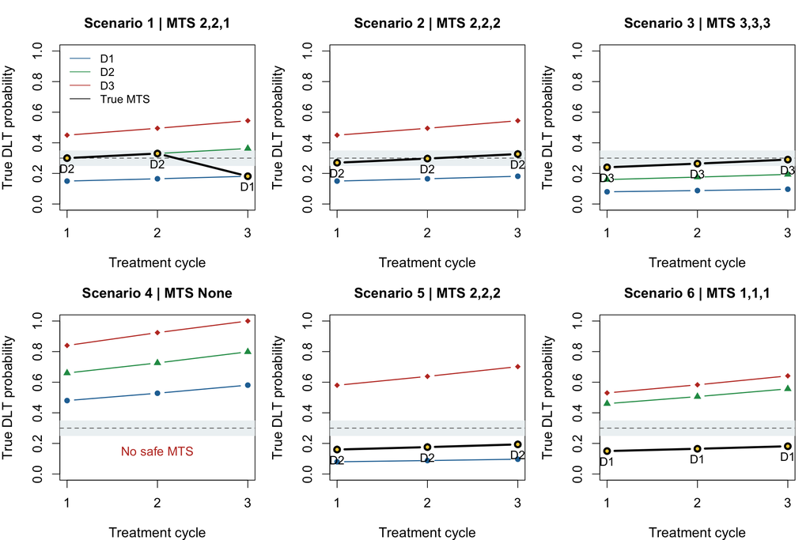

True dose/cycle probabilities. Colored lines hold dose fixed; the black path follows the true MTS. Labels give its dose in each cycle.

For a nonincreasing sequence $s=(d_{s1},d_{s2},d_{s3})$, its true TPC is

$$q_s=\frac{1}{3}\sum_{j=1}^3p_{d_{sj},j}.$$

The next plot shows all ten nonincreasing candidate sequences against dose intensity $I_s=\sum_jd_{sj}$. Small horizontal offsets separate sequences with the same intensity; they do **not** impose a toxicity ordering. Blue points satisfy $p_{d_{sj},j}<0.35$ in every cycle, red points fail that criterion, and the gold point is the true MTS. A sequence can have TPC near 0.30 and still contain an unsafe dose/cycle cell.

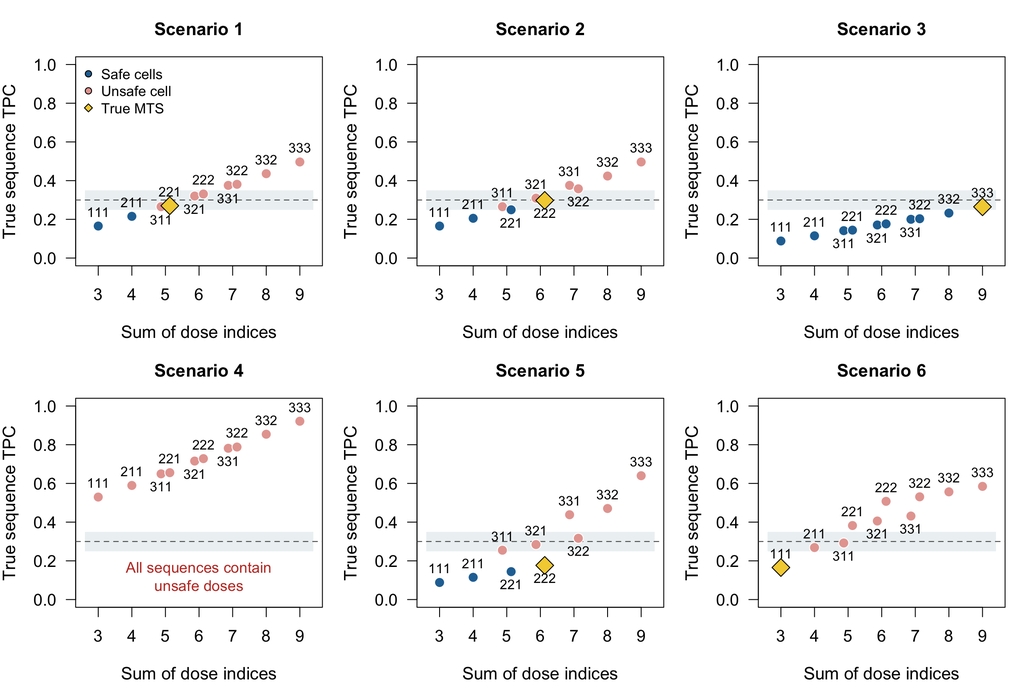

True sequence TPC and safety. Gold marks the true MTS; scenario 4 has none. Sequence labels concatenate the three dose indices.

Scenarios 1-2 have a moderately toxic lowest dose and only 15 patients, so early DLTs can limit exploration before the final recommendation. Scenario 3 has safe upper doses and permits escalation to (3,3,3). Scenario 4 tests the ability to stop, rather than successful selection of a safe sequence. In scenario 5 the D2-to-D3 toxicity jump leaves (2,2,2) as the highest safe path, even though its TPC is below the EI; scenario 6 leaves only (1,1,1) safe. These are explanations from the truth settings, not guarantees of selection performance. The simulation plots below show the actual operating behavior.

## 6.6 MTS selection and completed-sequence outcomes

For each published sequence, the selection probability and its Monte Carlo standard error are

$$\widehat\pi_s=\frac{1}{B}\sum_{b=1}^B\mathbf{1}\{\widehat s_b=s\},
\qquad \operatorname{MCSE}(\widehat\pi_s)
=\sqrt{\widehat\pi_s(1-\widehat\pi_s)/B}.$$

The mean and SD of DLTs below are calculated across completed patients with that actual sequence. Sequence allocation is their number divided by $15B$; patients with incomplete sequences are not assigned a completed sequence. These interpretations of the printed columns are stated explicitly for review. Selection/allocation numbers such as 0.190 are **proportions** (19.0%).

```r
comparison <- merge(published$selection, table3_summary$selection,
                    by = c("scenario", "sequence"), suffixes = c("_paper", "_sim"))
sequence_table <- with(comparison, data.frame(
  Scenario = scenario, Sequence = sequence,
  Paper_Pr = selection_paper, Sim_Pr = selection_sim,
  Difference = selection_sim - selection_paper, MCSE = mcse,
  Paper_DLT = sprintf("%.3f (%.3f)", mean_dlts_paper, sd_dlts_paper),
  Sim_DLT = sprintf("%.3f (%.3f)", mean_dlts_sim, sd_dlts_sim),
  Paper_allocation = allocation_paper, Sim_allocation = allocation_sim))
knitr::kable(sequence_table, digits = 3, row.names = FALSE)
```

| Scenario | Sequence | Paper_Pr | Sim_Pr | Difference | MCSE | Paper_DLT | Sim_DLT | Paper_allocation | Sim_allocation |
| --- | --- | --- | --- | --- | --- | --- | --- | --- | --- |
| 1 | 1,1,1 | 0.242 | 0.218 | -0.024 | 0.004 | 0.544 (0.671) | 0.543 (0.672) | 0.304 | 0.297 |
| 1 | 2,1,1 | 0.197 | 0.185 | -0.012 | 0.004 | 0.902 (0.769) | 0.889 (0.773) | 0.164 | 0.163 |
| 1 | 2,2,1 | 0.190 | 0.207 | 0.017 | 0.004 | 0.645 (0.625) | 0.644 (0.627) | 0.089 | 0.088 |
| 1 | 2,2,2 | 0.131 | 0.125 | -0.006 | 0.003 | 0.363 (0.481) | 0.367 (0.482) | 0.034 | 0.034 |
| 1 | 3,1,1 | 0.056 | 0.054 | -0.002 | 0.002 | 0.869 (0.756) | 0.874 (0.777) | 0.035 | 0.034 |
| 1 | 3,2,1 | 0.070 | 0.074 | 0.004 | 0.003 | 1.173 (0.800) | 1.154 (0.812) | 0.063 | 0.068 |
| 2 | 1,1,1 | 0.209 | 0.189 | -0.020 | 0.004 | 0.534 (0.666) | 0.536 (0.667) | 0.288 | 0.286 |
| 2 | 2,1,1 | 0.174 | 0.155 | -0.019 | 0.004 | 0.869 (0.771) | 0.867 (0.767) | 0.145 | 0.145 |
| 2 | 2,2,1 | 0.185 | 0.204 | 0.019 | 0.004 | 0.629 (0.627) | 0.621 (0.629) | 0.090 | 0.092 |
| 2 | 2,2,2 | 0.148 | 0.145 | -0.003 | 0.004 | 0.328 (0.469) | 0.332 (0.471) | 0.042 | 0.040 |
| 2 | 3,1,1 | 0.057 | 0.058 | 0.001 | 0.002 | 0.883 (0.761) | 0.884 (0.761) | 0.039 | 0.037 |
| 2 | 3,2,1 | 0.082 | 0.075 | -0.007 | 0.003 | 1.158 (0.818) | 1.158 (0.807) | 0.070 | 0.071 |
| 2 | 3,2,2 | 0.065 | 0.076 | 0.011 | 0.003 | 0.874 (0.682) | 0.873 (0.684) | 0.032 | 0.034 |
| 3 | 1,1,1 | 0.061 | 0.060 | -0.001 | 0.002 | 0.276 (0.503) | 0.283 (0.510) | 0.215 | 0.216 |
| 3 | 2,2,1 | 0.059 | 0.063 | 0.004 | 0.002 | 0.534 (0.579) | 0.529 (0.575) | 0.074 | 0.074 |
| 3 | 2,2,2 | 0.140 | 0.142 | 0.002 | 0.003 | 0.196 (0.397) | 0.193 (0.394) | 0.094 | 0.090 |
| 3 | 3,2,1 | 0.066 | 0.058 | -0.008 | 0.002 | 0.975 (0.782) | 0.962 (0.782) | 0.068 | 0.069 |
| 3 | 3,2,2 | 0.163 | 0.171 | 0.008 | 0.004 | 0.579 (0.627) | 0.577 (0.625) | 0.083 | 0.082 |
| 3 | 3,3,2 | 0.209 | 0.215 | 0.006 | 0.004 | 0.597 (0.630) | 0.606 (0.636) | 0.080 | 0.079 |
| 3 | 3,3,3 | 0.204 | 0.195 | -0.009 | 0.004 | 0.289 (0.453) | 0.296 (0.457) | 0.044 | 0.043 |
| 4 | 1,1,1 | 0.008 | 0.026 | 0.018 | 0.002 | 1.390 (0.855) | 1.518 (0.862) | 0.202 | 0.280 |
| 4 | 2,1,1 | NA | 0.002 | NA | 0.000 | 1.687 (0.861) | 1.681 (0.837) | 0.021 | 0.023 |
| 5 | 1,1,1 | 0.080 | 0.093 | 0.013 | 0.003 | 0.276 (0.502) | 0.284 (0.511) | 0.214 | 0.215 |
| 5 | 2,1,1 | 0.052 | 0.059 | 0.007 | 0.002 | 0.758 (0.728) | 0.726 (0.738) | 0.052 | 0.054 |
| 5 | 2,2,1 | 0.136 | 0.152 | 0.016 | 0.004 | 0.552 (0.585) | 0.537 (0.578) | 0.092 | 0.083 |
| 5 | 2,2,2 | 0.397 | 0.371 | -0.026 | 0.005 | 0.195 (0.396) | 0.193 (0.395) | 0.129 | 0.106 |
| 5 | 3,2,1 | 0.073 | 0.049 | -0.024 | 0.002 | 1.250 (0.765) | 1.257 (0.756) | 0.071 | 0.078 |
| 5 | 3,2,2 | 0.183 | 0.190 | 0.007 | 0.004 | 0.889 (0.616) | 0.868 (0.619) | 0.107 | 0.108 |
| 6 | 1,1,1 | 0.450 | 0.452 | 0.002 | 0.005 | 0.543 (0.669) | 0.550 (0.668) | 0.373 | 0.349 |
| 6 | 2,1,1 | 0.283 | 0.255 | -0.028 | 0.004 | 0.987 (0.743) | 0.984 (0.748) | 0.225 | 0.229 |
| 6 | 2,2,1 | 0.136 | 0.159 | 0.023 | 0.004 | 0.758 (0.625) | 0.756 (0.623) | 0.062 | 0.064 |

Largest absolute selection difference: **2.83 percentage points**. 13 of 30 published selection entries differ by more than three combined Monte Carlo standard errors.

Only the paper’s printed sequence rows for scenarios 1-6 are compared above; all simulated sequences and “None” are available in `table3_summary$selection`.

## 6.7 Dose/cycle counts and early termination

Dose/cycle counts average over **all trials**, including early stops.

```r
cell_comparison <- merge(published$cells, table3_summary$cells,
                         by = c("scenario", "dose", "cycle"),
                         suffixes = c("_paper", "_sim"))
cell_table <- with(cell_comparison, data.frame(
  Scenario = scenario, Dose = dose, Cycle = cycle,
  Paper_DLT_of_N = sprintf("%.3f of %.3f", dlts_paper, n_paper),
  Sim_DLT_of_N = sprintf("%.3f of %.3f", dlts_sim, n_sim)))
knitr::kable(cell_table, row.names = FALSE)
```

| Scenario | Dose | Cycle | Paper_DLT_of_N | Sim_DLT_of_N |
| --- | --- | --- | --- | --- |
| 1 | 1 | 1 | 1.000 of 6.591 | 0.965 of 6.490 |
| 1 | 1 | 2 | 1.638 of 9.854 | 1.625 of 9.796 |
| 1 | 1 | 3 | 1.983 of 10.844 | 1.971 of 10.795 |
| 1 | 2 | 1 | 1.784 of 5.847 | 1.776 of 5.892 |
| 1 | 2 | 2 | 1.486 of 4.518 | 1.499 of 4.568 |
| 1 | 2 | 3 | 1.315 of 3.649 | 1.343 of 3.683 |
| 1 | 3 | 1 | 1.061 of 2.373 | 1.112 of 2.478 |
| 1 | 3 | 2 | 0.177 of 0.348 | 0.188 of 0.380 |
| 1 | 3 | 3 | 0.078 of 0.141 | 0.076 of 0.146 |
| 2 | 1 | 1 | 0.936 of 6.246 | 0.918 of 6.192 |
| 2 | 1 | 2 | 1.546 of 9.369 | 1.520 of 9.330 |
| 2 | 1 | 3 | 1.883 of 10.434 | 1.896 of 10.418 |
| 2 | 2 | 1 | 1.543 of 5.763 | 1.551 of 5.806 |
| 2 | 2 | 2 | 1.439 of 4.818 | 1.443 of 4.880 |
| 2 | 2 | 3 | 1.289 of 3.930 | 1.303 of 3.978 |
| 2 | 3 | 1 | 1.247 of 2.766 | 1.290 of 2.860 |
| 2 | 3 | 2 | 0.240 of 0.483 | 0.261 of 0.532 |
| 2 | 3 | 3 | 0.114 of 0.207 | 0.121 of 0.226 |
| 3 | 1 | 1 | 0.340 of 4.325 | 0.362 of 4.393 |
| 3 | 1 | 2 | 0.518 of 5.961 | 0.538 of 6.052 |
| 3 | 1 | 3 | 0.670 of 6.899 | 0.668 of 6.969 |
| 3 | 2 | 1 | 0.809 of 5.075 | 0.816 of 5.071 |
| 3 | 2 | 2 | 1.136 of 6.468 | 1.139 of 6.415 |
| 3 | 2 | 3 | 1.210 of 6.310 | 1.231 of 6.294 |
| 3 | 3 | 1 | 1.334 of 5.572 | 1.316 of 5.527 |
| 3 | 3 | 2 | 0.664 of 2.531 | 0.666 of 2.516 |
| 3 | 3 | 3 | 0.501 of 1.738 | 0.501 of 1.712 |
| 4 | 1 | 1 | 3.795 of 7.849 | 4.521 of 9.393 |
| 4 | 1 | 2 | 3.118 of 5.876 | 3.919 of 7.432 |
| 4 | 1 | 3 | 1.962 of 3.400 | 2.661 of 4.579 |
| 4 | 2 | 1 | 0.527 of 0.800 | 0.602 of 0.916 |
| 4 | 2 | 2 | 0.039 of 0.054 | 0.036 of 0.050 |
| 4 | 2 | 3 | 0.012 of 0.016 | 0.011 of 0.015 |
| 4 | 3 | 1 | 0.018 of 0.021 | 0.023 of 0.026 |
| 4 | 3 | 2 | 0.000 of 0.000 | 0.000 of 0.000 |
| 4 | 3 | 3 | 0.000 of 0.000 | 0.000 of 0.000 |
| 5 | 1 | 1 | 0.354 of 4.364 | 0.359 of 4.384 |
| 5 | 1 | 2 | 0.540 of 6.222 | 0.545 of 6.241 |
| 5 | 1 | 3 | 0.689 of 7.133 | 0.702 of 7.171 |
| 5 | 2 | 1 | 1.060 of 6.583 | 1.012 of 6.304 |
| 5 | 2 | 2 | 1.313 of 7.511 | 1.292 of 7.306 |
| 5 | 2 | 3 | 1.363 of 6.977 | 1.326 of 6.794 |
| 5 | 3 | 1 | 2.334 of 4.023 | 2.494 of 4.304 |
| 5 | 3 | 2 | 0.785 of 1.223 | 0.909 of 1.438 |
| 5 | 3 | 3 | 0.584 of 0.836 | 0.703 of 1.012 |
| 6 | 1 | 1 | 1.203 of 7.997 | 1.175 of 7.825 |
| 6 | 1 | 2 | 1.884 of 11.432 | 1.868 of 11.342 |
| 6 | 1 | 3 | 2.205 of 12.120 | 2.164 of 11.983 |
| 6 | 2 | 1 | 2.665 of 5.810 | 2.764 of 6.025 |
| 6 | 2 | 2 | 1.601 of 3.196 | 1.715 of 3.381 |
| 6 | 2 | 3 | 1.351 of 2.435 | 1.489 of 2.670 |
| 6 | 3 | 1 | 0.514 of 0.970 | 0.538 of 1.022 |
| 6 | 3 | 2 | 0.024 of 0.041 | 0.024 of 0.044 |
| 6 | 3 | 3 | 0.005 of 0.009 | 0.004 of 0.007 |

```r
stop_comparison <- merge(published$early_stop, table3_summary$early_stop,
                         by = "scenario", suffixes = c("_paper", "_sim"))
stop_comparison[-1] <- 100 * stop_comparison[-1]
knitr::kable(stop_comparison, digits = 2, row.names = FALSE,
             caption = "Early termination (%)")
```

Early termination (%)

| scenario | stopped_early_paper | stopped_early_sim |
| --- | --- | --- |
| 1 | 3.32 | 3.98 |
| 2 | 3.75 | 3.99 |
| 3 | 0.43 | 0.27 |
| 4 | 99.21 | 96.30 |
| 5 | 0.44 | 0.25 |
| 6 | 4.01 | 3.61 |

## 6.8 Graphical comparison with the paper

The bars compare selection of the true MTS in scenarios with a safe MTS, and early stopping in all scenarios. Scenario 4 has no safe MTS and is therefore assessed by early stopping rather than by a reported true-MTS selection probability. Error bars show simulation Monte Carlo uncertainty.

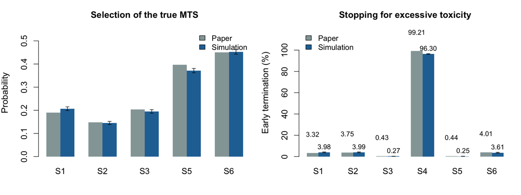

Published versus simulated operating characteristics. Error bars are 95% Monte Carlo intervals for the simulation; they do not include uncertainty in the paper estimates.

The next plots compare **every numerically reported sequence-selection probability**, not just selection of the true MTS. Agreement would place points near the diagonal. Labels identify the true MTS and the two largest selection discrepancies within a scenario; the gold point marks the true MTS when it appears among the printed rows.

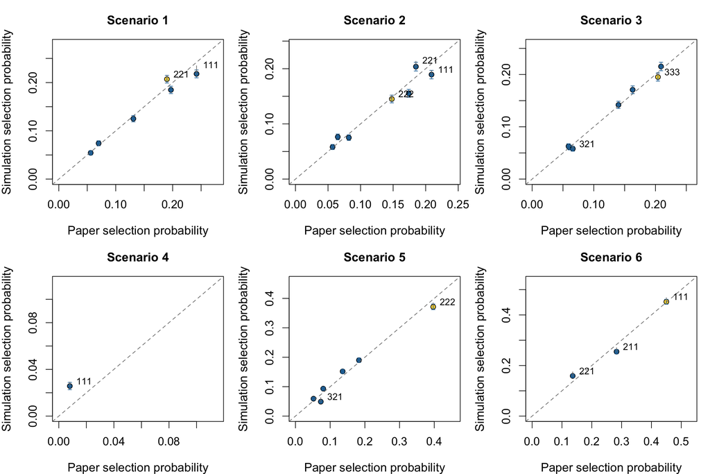

Selection probabilities from the paper and simulation. The diagonal indicates agreement. Vertical intervals show 95% simulation Monte Carlo uncertainty.

Finally, dose/cycle allocation can agree even when final MTS selection differs. This comparison helps separate the trial-allocation engine from the final PAVA/voting convention. Each point is one dose/cycle cell.

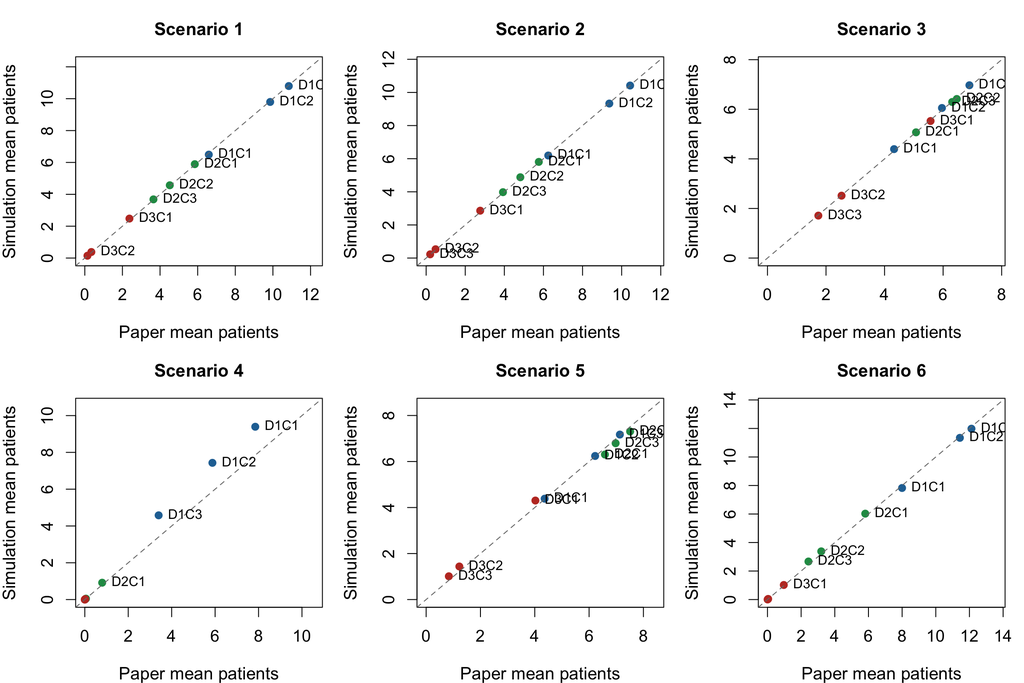

Mean patient allocation per dose/cycle cell, averaged over all trials. The diagonal indicates agreement with Table 3.